```python
import pandas as pd
import scipy.stats
import numpy as np
from scipy.optimize import minimize
from pandas_datareader import data
import statsmodels.api as sm
import seaborn as sns
import matplotlib.pyplot as plt
import matplotlib.dates as mdts
```

# 1. Util Functions

```python
def annualize_rets(r, periods_per_year):
    """
    Annualizes a set of returns
    We should infer the periods per year

    """
    compounded_growth = (1+r).prod()
    n_periods = r.shape[0]
    return compounded_growth**(periods_per_year/n_periods)-1


def annualize_vol(r, periods_per_year):
    """
    Annualizes the vol of a set of returns
    """
    return r.std()*(periods_per_year**0.5)


def sharpe_ratio(r, riskfree_rate, periods_per_year):
    """
    Computes the annualized sharpe ratio of a set of returns
    """
    # convert the annual riskfree rate to per period
    rf_per_period = (1+riskfree_rate)**(1/periods_per_year)-1
    excess_ret = r - rf_per_period
    ann_ex_ret = annualize_rets(excess_ret, periods_per_year)
    ann_vol = annualize_vol(r, periods_per_year)
    return ann_ex_ret/ann_vol


def drawdown(return_series: pd.Series):
    """
    Takes a time series of asset returns.
    returns a DataFrame with columns for
    the wealth index,
    the previous peaks, and
    the percentage drawdown
    """
    wealth_index = 1000*(1+return_series).cumprod()
    previous_peaks = wealth_index.cummax()
    drawdowns = (wealth_index - previous_peaks)/previous_peaks

    max_drawdown = drawdowns.min()
    trough_date = drawdowns.idxmin().strftime('%B %d, %Y')
    peak_date = previous_peaks[:trough_date].idxmax().strftime('%B %d, %Y')
    return pd.DataFrame({"Wealth": wealth_index,
                         "Previous Peak": previous_peaks,
                         "Drawdown": drawdowns,
                         "PeakDate": peak_date,
                         "TroughDate": trough_date})


def skewness(r):
    """
    Computes the skewness of the supplied Series or DataFrame
    Returns a float or a Series
    """
    return scipy.stats.skew(r)

def kurtosis(r):
    """
    Computes the excess kurtosis of the supplied Series or DataFrame
    Returns a float or a Series
    """
    return scipy.stats.kurtosis(r)


def var_historic(r, level=5):
    """
    Returns the historic Value at Risk at a specified level
    i.e. returns the number such that "level" percent of the returns
    fall below that number, and the (100-level) percent are above
    """
    if isinstance(r, pd.DataFrame):
        return r.aggregate(var_historic, level=level)
    elif isinstance(r, pd.Series):
        return -np.percentile(r, level)
    else:
        raise TypeError("Expected r to be a Series or DataFrame")


def cvar_historic(r, level=5):
    """
    Computes the Conditional VaR of Series or DataFrame
    """
    if isinstance(r, pd.Series):
        is_beyond = r <= -var_historic(r, level=level)
        return -r[is_beyond].mean()
    elif isinstance(r, pd.DataFrame):
        return r.aggregate(cvar_historic, level=level)
    else:
        raise TypeError("Expected r to be a Series or DataFrame")


def summary_stats(r, riskfree_rate=0):
    """
    Return a DataFrame that contains aggregated summary stats for the returns in the columns of r
    """
    ann_r = r.aggregate(annualize_rets, periods_per_year=250)
    ann_vol = r.aggregate(annualize_vol, periods_per_year=250)
    ann_sr = r.aggregate(sharpe_ratio, riskfree_rate=riskfree_rate, periods_per_year=250)
    dd = r.aggregate(lambda r: drawdown(r).Drawdown.min())
    peak_date = r.aggregate(lambda r: drawdown(r).PeakDate.iloc[0])
    trough_date = r.aggregate(lambda r: drawdown(r).TroughDate.iloc[0])
    skew = r.aggregate(skewness)
    kurt = r.aggregate(kurtosis)
    hist_var5 = r.aggregate(var_historic)
    hist_cvar5 = r.aggregate(cvar_historic)
    return pd.DataFrame({
        "Annualized Return": ann_r,
        "Annualized Vol": ann_vol,
        "Skewness": skew,
        "Excess Kurtosis": kurt,
        "Historical VaR (5%)": hist_var5,
        "Historic CVaR (5%)": hist_cvar5,
        "Sharpe Ratio": ann_sr,
        "Max Drawdown": dd,
        "Peak Date": peak_date,
        "Trough Date":trough_date
    })


def style_analysis(dependent_variable, explanatory_variables):
    """
    Returns the optimal weights that minimizes the Tracking error between
    a portfolio of the explanatory variables and the dependent variable
    """
    n = explanatory_variables.shape[1]
    init_guess = np.repeat(1/n, n)
    bounds = ((0.0, 1.0),) * n # an N-tuple of 2-tuples!
    # construct the constraints
    weights_sum_to_1 = {'type': 'eq',
                        'fun': lambda weights: np.sum(weights) - 1
    }
    solution = minimize(portfolio_tracking_error, init_guess,
                       args=(dependent_variable, explanatory_variables,), method='SLSQP',
                       options={'disp': False},
                       constraints=(weights_sum_to_1,),
                       bounds=bounds)
    weights = pd.Series(solution.x, index=explanatory_variables.columns)
    return weights

def tracking_error(r_a, r_b):
    """
    Returns the Tracking Error between the two return series
    """
    return np.sqrt(((r_a - r_b)**2).sum())

def portfolio_tracking_error(weights, ref_r, bb_r):
    """
    returns the tracking error between the reference returns
    and a portfolio of building block returns held with given weights
    """
    return tracking_error(ref_r, (weights*bb_r).sum(axis=1))

def compound(r):
    """
    returns the result of compounding the set of returns in r
    """
    return np.expm1(np.log1p(r).sum())

def get_fff_returns(label):

    """
    load the Fama-French Dataset for factor returns
    """

    rets = data.DataReader(label,'famafrench',start='1926/01/01')[0]/100

    return rets

def get_ind_market_caps(label, weights=False):
    '''
    Load the industry portfolio data and derive the market caps
    '''

    ind_nfirms = data.DataReader(label,'famafrench',start='1926/01/01')[4]
    ind_size = data.DataReader(label,'famafrench',start='1926/01/01')[5]
    ind_mktcap = ind_nfirms * ind_size
    if weights:
        total_mktcap = ind_mktcap.sum(axis=1)
        ind_capweight = ind_mktcap.divide(total_mktcap, axis="rows")
        return ind_capweight
    #else
    return ind_mktcap


def regress(dependent_variable, explanatory_variables, alpha=True):
    """
    Runs a linear regression to decompose the dependent variable into the explanatory variables
    returns an object of type statsmodel's RegressionResults on which you can call
       .summary() to print a full summary
       .params for the coefficients
       .tvalues and .pvalues for the significance levels
       .rsquared_adj and .rsquared for quality of fit
    """
    if alpha:
        explanatory_variables = explanatory_variables.copy()
        explanatory_variables["Alpha"] = 1

    lm = sm.OLS(dependent_variable, explanatory_variables).fit()
    return lm
```

# 2. ETF Analysis

In this Section, I focus on analyzing some ETFs historical risk and return charactersitics. These ETFs are primarily index ETFs used to adjust beta of the portfolio. I also include a few ETFs that have performed very well in 2025.

```python
filenames = ['IVV','SPY','XIU','MCHI','SPYG','SPSM','SPYV','OEF','ZLB','XMV']
ETF_data_dict = {}
returns_data_dict = {}

for filename in filenames:
    ETF_data = pd.read_excel(filename+'.xlsx',skiprows=2,index_col=0,parse_dates=True)
    ETF_data.sort_index(inplace=True)
    ETF_data_dict[filename] = ETF_data
    returns_data_dict[filename] = ETF_data['Price'].pct_change().dropna()
    returns_data_dict[filename] = returns_data_dict[filename].to_frame(name=filename)

returns_data = [returns_data_dict[key] for key in filenames]
dat = pd.concat(returns_data, axis=1)
```

```python
#pd.set_option('display.max_rows', None)
dat
```

| Date | IVV | SPY | XIU | MCHI | SPYG | SPSM | SPYV | OEF | ZLB | XMV |
| --- | --- | --- | --- | --- | --- | --- | --- | --- | --- | --- |
| 1993-02-01 | NaN | 0.007112 | NaN | NaN | NaN | NaN | NaN | NaN | NaN | NaN |
| 1993-02-02 | NaN | 0.002119 | NaN | NaN | NaN | NaN | NaN | NaN | NaN | NaN |
| 1993-02-03 | NaN | 0.010571 | NaN | NaN | NaN | NaN | NaN | NaN | NaN | NaN |
| 1993-02-04 | NaN | 0.004184 | NaN | NaN | NaN | NaN | NaN | NaN | NaN | NaN |
| 1993-02-05 | NaN | -0.000694 | NaN | NaN | NaN | NaN | NaN | NaN | NaN | NaN |
| ... | ... | ... | ... | ... | ... | ... | ... | ... | ... | ... |
| 2026-01-05 | 0.006704 | 0.006660 | 0.009735 | 0.006909 | 0.003841 | 0.013108 | 0.010007 | 0.005170 | 0.000518 | 0.002550 |
| 2026-01-06 | 0.005935 | 0.005947 | 0.004087 | 0.000638 | 0.005412 | 0.013982 | 0.006953 | 0.002761 | 0.003104 | 0.003996 |
| 2026-01-07 | -0.003252 | -0.003223 | -0.008663 | -0.013236 | 0.002506 | -0.007203 | -0.009839 | -0.000609 | -0.004985 | -0.007418 |
| 2026-01-08 | -0.000116 | -0.000102 | 0.009055 | 0.006464 | -0.008425 | 0.013889 | 0.009240 | -0.001015 | 0.006393 | 0.008932 |
| 2026-01-09 | 0.006541 | 0.006613 | 0.006260 | -0.000963 | 0.007656 | 0.007156 | 0.005700 | 0.004586 | 0.005322 | 0.005781 |

8422 rows × 10 columns

```python
dat.dropna()
```

| Date | IVV | SPY | XIU | MCHI | SPYG | SPSM | SPYV | OEF | ZLB | XMV |
| --- | --- | --- | --- | --- | --- | --- | --- | --- | --- | --- |
| 2013-07-10 | 0.000422 | 0.000375 | 0.000565 | -0.001983 | 0.002134 | 0.002985 | -0.001063 | -0.000538 | 0.003745 | -0.004178 |
| 2013-07-11 | 0.014453 | 0.013608 | 0.014108 | 0.051155 | 0.016239 | 0.015292 | 0.013002 | 0.012789 | 0.012793 | 0.012587 |
| 2013-07-12 | -0.000356 | 0.000418 | -0.003339 | -0.020317 | 0.000917 | 0.004478 | 0.001560 | 0.001196 | -0.002105 | 0.001842 |
| 2013-07-15 | 0.004454 | 0.003851 | 0.007817 | 0.010369 | 0.000917 | 0.004701 | 0.003295 | 0.002523 | 0.021097 | 0.013787 |
| 2013-07-16 | -0.004197 | -0.003747 | -0.001662 | 0.005012 | -0.003793 | -0.001775 | -0.004488 | -0.002781 | -0.005682 | -0.002720 |
| ... | ... | ... | ... | ... | ... | ... | ... | ... | ... | ... |
| 2026-01-05 | 0.006704 | 0.006660 | 0.009735 | 0.006909 | 0.003841 | 0.013108 | 0.010007 | 0.005170 | 0.000518 | 0.002550 |
| 2026-01-06 | 0.005935 | 0.005947 | 0.004087 | 0.000638 | 0.005412 | 0.013982 | 0.006953 | 0.002761 | 0.003104 | 0.003996 |
| 2026-01-07 | -0.003252 | -0.003223 | -0.008663 | -0.013236 | 0.002506 | -0.007203 | -0.009839 | -0.000609 | -0.004985 | -0.007418 |
| 2026-01-08 | -0.000116 | -0.000102 | 0.009055 | 0.006464 | -0.008425 | 0.013889 | 0.009240 | -0.001015 | 0.006393 | 0.008932 |
| 2026-01-09 | 0.006541 | 0.006613 | 0.006260 | -0.000963 | 0.007656 | 0.007156 | 0.005700 | 0.004586 | 0.005322 | 0.005781 |

3081 rows × 10 columns

```python
summary = summary_stats(dat.dropna(), riskfree_rate=0)
summary = summary.style.format(formatter="{:.3%}",subset=["Annualized Return","Annualized Vol", "Historical VaR (5%)","Historic CVaR (5%)","Max Drawdown"])
summary = summary.format(formatter="{:.3}",subset=["Sharpe Ratio","Skewness","Excess Kurtosis"])
summary
```

|  | Annualized Return | Annualized Vol | Skewness | Excess Kurtosis | Historical VaR (5%) | Historic CVaR (5%) | Sharpe Ratio | Max Drawdown | Peak Date | Trough Date |
| --- | --- | --- | --- | --- | --- | --- | --- | --- | --- | --- |
| IVV | 10.439% | 17.178% | -0.387 | 15.4 | 1.634% | 2.631% | 0.608 | -33.903% | February 19, 2020 | March 23, 2020 |
| SPY | 10.440% | 17.078% | -0.342 | 14.8 | 1.622% | 2.617% | 0.611 | -34.105% | February 19, 2020 | March 23, 2020 |
| XIU | 7.613% | 14.672% | -0.734 | 37.1 | 1.329% | 2.136% | 0.519 | -35.926% | February 19, 2020 | March 23, 2020 |
| MCHI | 2.552% | 26.811% | 0.525 | 10.3 | 2.643% | 3.712% | 0.0952 | -63.355% | February 17, 2021 | February 02, 2024 |
| SPYG | 13.147% | 19.266% | -0.217 | 11.3 | 1.884% | 2.975% | 0.682 | -34.663% | November 19, 2021 | October 14, 2022 |
| SPSM | 5.145% | 21.711% | -0.496 | 9.52 | 2.022% | 3.139% | 0.237 | -44.673% | August 31, 2018 | March 23, 2020 |
| SPYV | 7.146% | 16.268% | -0.524 | 17.3 | 1.491% | 2.450% | 0.439 | -37.489% | February 12, 2020 | March 23, 2020 |
| OEF | 11.222% | 17.463% | -0.291 | 14.5 | 1.646% | 2.668% | 0.643 | -31.436% | February 19, 2020 | March 23, 2020 |
| ZLB | 9.260% | 11.809% | -1.39 | 45.1 | 0.977% | 1.684% | 0.784 | -33.959% | February 18, 2020 | March 23, 2020 |
| XMV | 7.456% | 12.479% | -1.24 | 48.0 | 1.036% | 1.786% | 0.597 | -35.578% | February 19, 2020 | March 23, 2020 |

With these style ETFs, we can estiamte some thematic ETF's exposure to these style factors.

```python
# SPYG: S&P 500 Growth ETF
# OEF: Large Cap
# SPYV: S&P 500 Value ETF
# SPSM: S&P 600 Small Cap
weights = style_analysis(dat['ZLB'].dropna(),dat[['SPYG','SPYV','SPSM','OEF']].dropna())
weights.sort_values(ascending=False).round(4)*100
```

```
SPYV    85.26
OEF      9.01
SPYG     5.73
SPSM     0.00
dtype: float64
```

```python
weights = style_analysis(dat['XMV'].dropna(),dat[['SPYG','SPYV','SPSM','OEF']].dropna())
weights.sort_values(ascending=False).round(4)*100
```

```
SPYV    87.59
OEF     12.41
SPYG     0.00
SPSM     0.00
dtype: float64
```

```python
# use momentum to check the trading signals
ETF_name_dict = {
    'IVV':  'iShares Core S&P 500 ETF',
    'SPY': 'SPDR S&P 500 ETF Trust',
    'XIU': 'iShares S&P/TSX 60 Index ETF',
    'MCHI': 'iShares MSCI China ETF',
    'SPYG': 'SPDR S&P 500 Growth ETF',
    'SPSM': 'SPDR S&P 600 Small Cap ETF',
    'SPYV': 'SPDR S&P 500 Value ETF',
    'OEF': 'iShares S&P 100 ETF',
    'ZLB': 'BMO Low Volatility Canadian Equity ETF',
    'XMV': 'iShares MSCI Canada Minimum Volatility Index ETF',

}
ETF_name = 'ZLB'
full_df = pd.read_excel(ETF_name + '.xlsx',skiprows=2,index_col=0,parse_dates=True)
full_df.dropna(inplace=True)
full_df.sort_index(inplace=True)
full_df['Momentum'] =full_df['Price'] - full_df['Price'].shift(10)
```

```python
full_df.head(20)
```

| Date | Price | CVol | % Change | Open | Low | High | NAV | Total Return (Gross) | % Return | Cumulative Return % | Momentum |
| --- | --- | --- | --- | --- | --- | --- | --- | --- | --- | --- | --- |
| 2011-10-28 | 15.05 | 2200.0 | -0.528751 | 15.13 | 15.05 | 15.13 | 15.0303 | 15.05 | -0.528751 | -0.528751 | NaN |
| 2011-10-31 | 15.02 | 3730.0 | -0.199336 | 15.12 | 15.02 | 15.12 | 14.9814 | 15.02 | -0.199336 | -0.727032 | NaN |
| 2011-11-01 | 14.83 | 2976.0 | -1.264980 | 14.81 | 14.81 | 14.83 | 15.0045 | 14.83 | -1.264980 | -1.982816 | NaN |
| 2011-11-02 | 14.96 | 1450.0 | 0.876601 | 15.06 | 14.96 | 15.06 | 14.9803 | 14.96 | 0.876601 | -1.123596 | NaN |
| 2011-11-03 | 15.17 | 1613.0 | 1.403743 | 15.10 | 15.05 | 15.18 | 15.1637 | 15.17 | 1.403743 | 0.264375 | NaN |
| 2011-11-04 | 15.16 | 400.0 | -0.065920 | 15.16 | 15.16 | 15.16 | 15.1638 | 15.16 | -0.065920 | 0.198282 | NaN |
| 2011-11-07 | 15.15 | 200.0 | -0.065963 | 15.15 | 15.15 | 15.15 | 15.1943 | 15.15 | -0.065963 | 0.132188 | NaN |
| 2011-11-08 | 15.19 | 1565.0 | 0.264026 | 15.27 | 15.19 | 15.27 | 15.2393 | 15.19 | 0.264026 | 0.396563 | NaN |
| 2011-11-09 | 15.10 | 4690.0 | -0.592495 | 15.13 | 15.10 | 15.16 | 15.1029 | 15.10 | -0.592495 | -0.198282 | NaN |
| 2011-11-10 | 15.11 | 7020.0 | 0.066225 | 15.09 | 15.09 | 15.11 | 15.0931 | 15.11 | 0.066225 | -0.132188 | NaN |
| 2011-11-11 | 15.19 | 700.0 | 0.529451 | 15.17 | 15.17 | 15.19 | 15.1972 | 15.19 | 0.529451 | 0.396563 | 0.14 |
| 2011-11-14 | 15.20 | 13325.0 | 0.065833 | 15.20 | 15.20 | 15.20 | 15.1856 | 15.20 | 0.065833 | 0.462657 | 0.18 |
| 2011-11-15 | 15.26 | 3645.0 | 0.394737 | 15.18 | 15.18 | 15.26 | 15.2561 | 15.26 | 0.394737 | 0.859220 | 0.43 |
| 2011-11-21 | 15.03 | 300.0 | -0.562355 | 15.03 | 15.03 | 15.03 | 15.1336 | 15.03 | -0.562355 | -0.660939 | 0.07 |
| 2011-11-23 | 15.04 | 5285.0 | -0.594845 | 15.04 | 15.00 | 15.05 | 15.0273 | 15.04 | -0.594845 | -0.594845 | -0.13 |
| 2011-11-29 | 15.12 | 1430.0 | -0.066094 | 15.10 | 15.10 | 15.12 | 15.1095 | 15.12 | -0.066094 | -0.066094 | -0.04 |
| 2011-11-30 | 15.20 | 12850.0 | 0.529101 | 15.23 | 15.20 | 15.23 | 15.3563 | 15.20 | 0.529101 | 0.462657 | 0.05 |
| 2011-12-01 | 15.33 | 5025.0 | 0.855263 | 15.40 | 15.33 | 15.40 | 15.3173 | 15.33 | 0.855263 | 1.321877 | 0.14 |
| 2011-12-02 | 15.27 | 3505.0 | -0.391389 | 15.35 | 15.24 | 15.35 | 15.2303 | 15.27 | -0.391389 | 0.925314 | 0.17 |
| 2011-12-05 | 15.32 | 3005.0 | 0.327439 | 15.34 | 15.30 | 15.34 | 15.2815 | 15.32 | 0.327439 | 1.255783 | 0.21 |

```python
full_df.tail(20)
```

| Date | Price | CVol | % Change | Open | Low | High | NAV | Total Return (Gross) | % Return | Cumulative Return % | Momentum |
| --- | --- | --- | --- | --- | --- | --- | --- | --- | --- | --- | --- |
| 2025-12-10 | 57.34 | 33562.0 | 0.104749 | 57.24 | 57.18 | 57.42 | 57.32104 | 83.128040 | 0.104760 | 449.425248 | -0.82 |
| 2025-12-11 | 57.39 | 63815.0 | 0.087199 | 57.35 | 57.30 | 57.53 | 57.39847 | 83.200520 | 0.087191 | 449.904296 | -0.83 |
| 2025-12-12 | 57.50 | 79195.0 | 0.191671 | 57.58 | 57.30 | 57.62 | 57.49725 | 83.359990 | 0.191669 | 450.958295 | -0.67 |
| 2025-12-15 | 57.79 | 66150.0 | 0.504348 | 57.60 | 57.60 | 57.87 | 57.77365 | 83.780420 | 0.504355 | 453.737079 | -0.22 |
| 2025-12-16 | 57.73 | 56999.0 | -0.103824 | 57.72 | 57.68 | 57.86 | 57.71499 | 83.693430 | -0.103831 | 453.162128 | 0.14 |
| 2025-12-17 | 57.70 | 60786.0 | -0.051966 | 57.80 | 57.47 | 57.80 | 57.69116 | 83.649940 | -0.051963 | 452.874686 | 0.41 |
| 2025-12-18 | 57.88 | 64186.0 | 0.311958 | 57.80 | 57.74 | 58.04 | 57.88191 | 83.910900 | 0.311967 | 454.599471 | 0.14 |
| 2025-12-19 | 57.94 | 68182.0 | 0.103663 | 58.02 | 57.90 | 58.21 | 57.91840 | 83.997870 | 0.103646 | 455.174289 | 0.38 |
| 2025-12-22 | 58.20 | 65490.0 | 0.448740 | 57.94 | 57.65 | 58.21 | 58.17844 | 84.374810 | 0.448749 | 457.665631 | 0.87 |
| 2025-12-23 | 58.22 | 71292.0 | 0.034364 | 58.13 | 58.13 | 58.31 | 58.24543 | 84.403810 | 0.034370 | 457.857303 | 0.94 |
| 2025-12-24 | 58.16 | 24260.0 | -0.103057 | 58.23 | 58.16 | 58.30 | 58.14945 | 84.316820 | -0.103064 | 457.282353 | 0.82 |
| 2025-12-29 | 58.26 | 51529.0 | 0.171939 | 57.99 | 57.99 | 58.37 | 58.24680 | 84.461790 | 0.171935 | 458.240516 | 0.87 |
| 2025-12-30 | 57.98 | 43438.0 | -0.480604 | 58.03 | 57.98 | 58.17 | 57.96817 | 84.461800 | 0.000012 | 458.240582 | 0.48 |
| 2025-12-31 | 57.94 | 55964.0 | -0.068989 | 57.96 | 57.90 | 58.02 | 57.92918 | 84.403530 | -0.068990 | 457.855453 | 0.15 |
| 2026-01-02 | 57.96 | 61879.0 | 0.034518 | 58.08 | 57.89 | 58.15 | 57.98995 | 84.432660 | 0.034513 | 458.047984 | 0.23 |
| 2026-01-05 | 57.99 | 102076.0 | 0.051760 | 58.20 | 57.99 | 58.22 | 57.97325 | 84.476364 | 0.051762 | 458.336841 | 0.29 |
| 2026-01-06 | 58.17 | 101866.0 | 0.310398 | 58.07 | 57.84 | 58.31 | 58.17110 | 84.738570 | 0.310390 | 460.069861 | 0.29 |
| 2026-01-07 | 57.88 | 76124.0 | -0.498539 | 58.07 | 57.88 | 58.20 | 57.90482 | 84.316124 | -0.498529 | 457.277753 | -0.06 |
| 2026-01-08 | 58.25 | 73052.0 | 0.639254 | 57.85 | 57.85 | 58.43 | 58.22522 | 84.855120 | 0.639256 | 460.840185 | 0.05 |
| 2026-01-09 | 58.56 | 42680.0 | 0.532189 | 58.34 | 58.34 | 58.63 | 58.57013 | 85.306710 | 0.532189 | 463.824917 | 0.34 |

```python
import plotly.express as px
fig = px.line(full_df, x=full_df.index, y='Momentum', title='Momentum of ' + ETF_name_dict[ETF_name])
fig.show()
```

# 3. Single Stock Analysis

Here are some stocks I'm currently watching and evaluate the option to buy/sell. If I want to analyze any single name, I can just change the stock name.

```python
stock_name_dict = {
    'UPS':'United Parcel Service, Inc. Class B',
    'META':'Meta Platforms Inc Class A',
    'TD': 'Toronto-Dominion Bank',
    'SAP': 'SAP SE Sponsored ADR',
    'MSFT': 'Microsoft Corporation',
    'LLY': 'Eli Lilly and Company',
    'ABX':'Barrick Mining Corporation',
    'DIS':'Walt Disney Company',
    'PINS': 'Pinterest, Inc. Class A',
    'APO':'Apollo Global Management Inc',
    'CEG': 'Constellation Energy Corporation',
    'QCOM': 'QUALCOMM Incorporated',
    'WPM': 'Wheaton Precious Metals Corp',
    'RBC': 'Royal Bank of Canada',
    'FTNT': 'Fortinet, Inc.',
    'ALB': 'Albermarle Corporation',
    'KDP':'Keurig Dr Peeper Inc',
    'FLR': 'Fluor Corporation'
}
stock_name = 'SAP'
stock_df = pd.read_excel(stock_name + '_full' + '.xlsx',skiprows=2,index_col=0,parse_dates=True)
stock_df.dropna(inplace=True)
stock_df.sort_index(inplace=True)
```

```python
stock_df.head()
```

| Date | Price | CVol | Change | % Change | % Return | Total Return (Gross) | Cumulative Return % | Open | High | Low | Cumulative Change % |
| --- | --- | --- | --- | --- | --- | --- | --- | --- | --- | --- | --- |
| 1999-05-11 | 25.749973 | 86088.09 | 1.000000 | 4.040408 | 4.040411 | 27.859112 | 3462.842436 | 24.999973 | 26.083305 | 24.583307 | 3193.109146 |
| 1999-05-12 | 26.249973 | 81756.09 | 0.500000 | 1.941750 | 1.941749 | 28.400066 | 3532.023889 | 26.249973 | 26.499973 | 26.041640 | 3257.053080 |
| 1999-05-14 | 26.791640 | 133176.15 | 0.541667 | 2.063495 | 2.063495 | 28.986100 | 3606.970528 | 26.666640 | 27.541637 | 26.666640 | 3326.325718 |
| 1999-05-17 | 26.399971 | 76620.08 | -0.391669 | -1.461908 | -1.461908 | 28.562350 | 3552.778044 | 26.916640 | 27.083305 | 25.833307 | 3276.236004 |
| 1999-05-18 | 26.833305 | 81144.09 | 0.433334 | 1.641418 | 1.641420 | 29.031178 | 3612.735458 | 26.749971 | 27.333305 | 26.749971 | 3331.654166 |

```python
stock_df.tail(10)
```

| Date | Price | CVol | Change | % Change | % Return | Total Return (Gross) | Cumulative Return % | Open | High | Low | Cumulative Change % |
| --- | --- | --- | --- | --- | --- | --- | --- | --- | --- | --- | --- |
| 2025-12-22 | 208.55 | 823023.0 | -0.25 | -0.119732 | -0.119731 | 316.26425 | 40346.360631 | 208.00 | 210.50 | 207.65 | 26571.014854 |
| 2025-12-23 | 207.70 | 620147.0 | -0.85 | -0.407576 | -0.407580 | 314.97522 | 40181.509333 | 208.95 | 209.20 | 207.50 | 26462.310166 |
| 2025-12-29 | 208.45 | 705141.0 | 0.75 | 0.361098 | 0.361095 | 316.11258 | 40326.963878 | 208.25 | 209.25 | 207.20 | 26558.226067 |
| 2025-12-30 | 208.35 | 608689.0 | -0.10 | -0.047973 | -0.047970 | 315.96094 | 40307.570962 | 208.70 | 209.60 | 207.80 | 26545.437281 |
| 2026-01-02 | 201.95 | 1856660.0 | -6.40 | -3.071754 | -3.071763 | 306.25537 | 39066.346308 | 207.90 | 208.70 | 200.05 | 25726.954926 |
| 2026-01-05 | 206.20 | 1312432.0 | 4.25 | 2.104481 | 2.104486 | 312.70047 | 39890.596405 | 200.20 | 206.20 | 199.60 | 26270.478365 |
| 2026-01-06 | 202.05 | 1510309.0 | -4.15 | -2.012609 | -2.012607 | 306.40704 | 39085.743060 | 203.60 | 203.95 | 200.60 | 25739.743713 |
| 2026-01-07 | 208.40 | 1604563.0 | 6.35 | 3.142786 | 3.142780 | 316.03674 | 40317.264862 | 203.55 | 208.40 | 202.75 | 26551.831674 |
| 2026-01-08 | 206.50 | 1215132.0 | -1.90 | -0.911708 | -0.911701 | 313.15543 | 39948.780269 | 208.65 | 209.25 | 205.90 | 26308.844725 |
| 2026-01-09 | 212.35 | 1743178.0 | 5.85 | 2.832930 | 2.832935 | 322.02692 | 41083.336211 | 207.00 | 214.25 | 206.00 | 27056.988752 |

## 3.1 Stock Historical Performance

```python
summary = summary_stats(stock_df['Price'].pct_change().dropna().to_frame().rename(columns={'Price':stock_name}),riskfree_rate=0)
summary = summary.style.format(formatter="{:.3%}",subset=["Annualized Return","Annualized Vol", "Historical VaR (5%)","Historic CVaR (5%)","Max Drawdown"])
summary = summary.format(formatter="{:.3}",subset=["Sharpe Ratio","Skewness","Excess Kurtosis"])
summary
```

|  | Annualized Return | Annualized Vol | Skewness | Excess Kurtosis | Historical VaR (5%) | Historic CVaR (5%) | Sharpe Ratio | Max Drawdown | Peak Date | Trough Date |
| --- | --- | --- | --- | --- | --- | --- | --- | --- | --- | --- |
| SAP | 8.164% | 34.519% | 0.669 | 13.4 | 3.105% | 5.000% | 0.237 | -85.454% | March 07, 2000 | October 07, 2002 |

```python
stock_df['Momentum'] = stock_df['Price'] - stock_df['Price'].shift(10)
stock_df['Momentum'].tail()
```

```
Date
2026-01-05   -3.45
2026-01-06   -4.60
2026-01-07    1.35
2026-01-08   -2.95
2026-01-09    3.55
Name: Momentum, dtype: float64
```

```python
import plotly.express as px
fig = px.line(stock_df, x=stock_df.index, y='Momentum', title='Momentum of ' + stock_name_dict[stock_name])
fig.show()
```

## 3.2 Stock Factor Analysis

I select traditional Fama French 3 factors from the data library.

```python
stock_df_m = stock_df['Price'].pct_change().dropna().resample('ME').apply(compound).to_period('M').to_frame().rename(columns={'Price':stock_name})
stock_df_m
```

| Date | SAP |
| --- | --- |
| 1999-05 | 0.055016 |
| 1999-06 | 0.006135 |
| 1999-07 | -0.051829 |
| 1999-08 | 0.067524 |
| 1999-09 | 0.090362 |
| ... | ... |
| 2025-09 | -0.016401 |
| 2025-10 | -0.015138 |
| 2025-11 | -0.070840 |
| 2025-12 | -0.000959 |
| 2026-01 | 0.019198 |

321 rows × 1 columns

```python
fff = get_fff_returns('F-F_Research_Data_Factors')
fff
```

| Date | Mkt-RF | SMB | HML | RF |
| --- | --- | --- | --- | --- |
| 1926-07 | 0.0289 | -0.0255 | -0.0239 | 0.0022 |
| 1926-08 | 0.0264 | -0.0114 | 0.0381 | 0.0025 |
| 1926-09 | 0.0038 | -0.0136 | 0.0005 | 0.0023 |
| 1926-10 | -0.0327 | -0.0014 | 0.0082 | 0.0032 |
| 1926-11 | 0.0254 | -0.0011 | -0.0061 | 0.0031 |
| ... | ... | ... | ... | ... |
| 2025-07 | 0.0198 | 0.0026 | -0.0127 | 0.0034 |
| 2025-08 | 0.0184 | 0.0387 | 0.0442 | 0.0038 |
| 2025-09 | 0.0339 | -0.0185 | -0.0105 | 0.0033 |
| 2025-10 | 0.0196 | -0.0055 | -0.0309 | 0.0037 |
| 2025-11 | -0.0013 | 0.0038 | 0.0376 | 0.0030 |

1193 rows × 4 columns

```python
factor_df = pd.merge(stock_df_m,fff,on='Date',how='inner')
factor_df
```

| Date | SAP | Mkt-RF | SMB | HML | RF |
| --- | --- | --- | --- | --- | --- |
| 1999-05 | 0.055016 | -0.0246 | 0.0332 | 0.0249 | 0.0034 |
| 1999-06 | 0.006135 | 0.0477 | 0.0323 | -0.0322 | 0.0040 |
| 1999-07 | -0.051829 | -0.0349 | 0.0248 | -0.0018 | 0.0038 |
| 1999-08 | 0.067524 | -0.0137 | -0.0095 | -0.0193 | 0.0039 |
| 1999-09 | 0.090362 | -0.0277 | 0.0312 | -0.0290 | 0.0039 |
| ... | ... | ... | ... | ... | ... |
| 2025-07 | -0.028472 | 0.0198 | 0.0026 | -0.0127 | 0.0034 |
| 2025-08 | -0.076156 | 0.0184 | 0.0387 | 0.0442 | 0.0038 |
| 2025-09 | -0.016401 | 0.0339 | -0.0185 | -0.0105 | 0.0033 |
| 2025-10 | -0.015138 | 0.0196 | -0.0055 | -0.0309 | 0.0037 |
| 2025-11 | -0.070840 | -0.0013 | 0.0038 | 0.0376 | 0.0030 |

319 rows × 5 columns

```python
stock_excess = pd.DataFrame(factor_df[stock_name] - factor_df['RF'],columns = [stock_name])
mkt_excess = pd.DataFrame(factor_df['Mkt-RF'])
mkt_excess['Value'] = factor_df['HML']
mkt_excess['Size'] = factor_df['SMB']
```

```python
result = regress(stock_excess, mkt_excess)
result.summary()
```

OLS Regression Results

| Dep. Variable: | SAP | R-squared: | 0.339 |
| --- | --- | --- | --- |
| Model: | OLS | Adj. R-squared: | 0.332 |
| Method: | Least Squares | F-statistic: | 53.79 |
| Date: | Sun, 11 Jan 2026 | Prob (F-statistic): | 4.25e-28 |
| Time: | 17:26:20 | Log-Likelihood: | 347.32 |
| No. Observations: | 319 | AIC: | -686.6 |
| Df Residuals: | 315 | BIC: | -671.6 |
| Df Model: | 3 |  |  |
| Covariance Type: | nonrobust |  |  |

|  | coef | std err | t | P>\|t\| | [0.025 | 0.975] |
| --- | --- | --- | --- | --- | --- | --- |
| Mkt-RF | 1.1884 | 0.105 | 11.312 | 0.000 | 0.982 | 1.395 |
| Value | -0.5414 | 0.134 | -4.031 | 0.000 | -0.806 | -0.277 |
| Size | 0.0432 | 0.150 | 0.289 | 0.773 | -0.251 | 0.338 |
| Alpha | 0.0028 | 0.005 | 0.611 | 0.542 | -0.006 | 0.012 |

| Omnibus: | 136.426 | Durbin-Watson: | 2.131 |
| --- | --- | --- | --- |
| Prob(Omnibus): | 0.000 | Jarque-Bera (JB): | 1225.890 |
| Skew: | 1.514 | Prob(JB): | 6.33e-267 |
| Kurtosis: | 12.114 | Cond. No. | 34.3 |

Notes:  
[1] Standard Errors assume that the covariance matrix of the errors is correctly specified.

## 3.3 Regime Analysis

I use various statistical models to predict near future regimes of the stock

### 3.3.1 Hidden Markov Model

```python
stock_df_w = stock_df['Price'].resample('W').ffill().pct_change().dropna().to_frame().rename(columns={'Price':stock_name})
stock_df_w
```

| Date | SAP |
| --- | --- |
| 1999-05-23 | 0.097978 |
| 1999-05-30 | -0.056657 |
| 1999-06-06 | -0.021021 |
| 1999-06-13 | -0.023006 |
| 1999-06-20 | 0.087912 |
| ... | ... |
| 2025-12-14 | -0.023681 |
| 2025-12-21 | 0.002882 |
| 2025-12-28 | -0.005268 |
| 2026-01-04 | -0.027684 |
| 2026-01-11 | 0.051498 |

1391 rows × 1 columns

```python
n_state = 3

from hmmlearn import hmm
onevar_n3 = hmm.GaussianHMM(n_components = n_state, covariance_type = 'full',n_iter = 1000, tol = 1e-04, random_state=42)

onevar_n3.fit(X=stock_df_w.values)

onevar_n3_fitquality = pd.Series(index=['AIC','BIC'],
                                 data=[onevar_n3.aic(stock_df_w.values),
                                       onevar_n3.bic(stock_df_w.values)])

onevar_n3_transmat = pd.DataFrame(index=[' '.join(['State', str(j)]) for j in range(n_state)],
                                      columns=[' '.join(['State', str(j)]) for j in range(n_state)],
                                      data=onevar_n3.transmat_)

onevar_n3_gaussparams = pd.DataFrame(index=onevar_n3_transmat.index, columns=['Mean', 'Std. dev.'], dtype=np.float64)
onevar_n3_gaussparams['Mean'] = onevar_n3.means_[:, 0]
onevar_n3_gaussparams['Std. dev.'] = np.sqrt(onevar_n3.covars_[:, :, 0])

onevar_n3_states = pd.DataFrame(index=stock_df_w.index,
                                columns=['State'] + ['='.join(['Prob. state', str(j)]) for j in range(n_state)],
                                dtype=np.float64)
onevar_n3_states['State'] = onevar_n3.predict(X=stock_df_w.values)
onevar_n3_states['State'] = onevar_n3_states['State'].astype(np.int8)
onevar_n3_states[['='.join(['Prob. state', str(j)]) for j in range(n_state)]] = onevar_n3.predict_proba(X=stock_df_w.values)
```

```python
onevar_n3_fitquality
```

```
AIC   -5117.631133
BIC   -5044.302238
dtype: float64
```

```python
onevar_n3_transmat.map(lambda x: '{:.4f}'.format(x))
```

|  | State 0 | State 1 | State 2 |
| --- | --- | --- | --- |
| State 0 | 0.9305 | 0.0660 | 0.0035 |
| State 1 | 0.5574 | 0.4426 | 0.0000 |
| State 2 | 0.0000 | 0.0163 | 0.9837 |

```python
onevar_n3_gaussparams.map(lambda x: '{:.4f}'.format(x))
```

|  | Mean | Std. dev. |
| --- | --- | --- |
| State 0 | 0.0024 | 0.0273 |
| State 1 | 0.0064 | 0.0514 |
| State 2 | 0.0016 | 0.0881 |

```python
onevar_n3_states.loc[onevar_n3_states.index >= pd.to_datetime('2025-06-01')].style.format(
    {'='.join(['Prob. state', str(j)]): '{:.1%}' for j in range(n_state)})
```

| Date | State | Prob. state=0 | Prob. state=1 | Prob. state=2 |
| --- | --- | --- | --- | --- |
| 2025-06-01 00:00:00 | 0 | 93.1% | 6.8% | 0.1% |
| 2025-06-08 00:00:00 | 0 | 89.1% | 10.8% | 0.1% |
| 2025-06-15 00:00:00 | 0 | 74.9% | 25.1% | 0.1% |
| 2025-06-22 00:00:00 | 0 | 90.3% | 9.7% | 0.0% |
| 2025-06-29 00:00:00 | 0 | 93.2% | 6.8% | 0.0% |
| 2025-07-06 00:00:00 | 0 | 95.0% | 5.0% | 0.0% |
| 2025-07-13 00:00:00 | 0 | 93.9% | 6.0% | 0.0% |
| 2025-07-20 00:00:00 | 0 | 87.8% | 12.2% | 0.0% |
| 2025-07-27 00:00:00 | 0 | 65.2% | 34.7% | 0.1% |
| 2025-08-03 00:00:00 | 0 | 87.9% | 12.1% | 0.0% |
| 2025-08-10 00:00:00 | 0 | 90.3% | 9.6% | 0.0% |
| 2025-08-17 00:00:00 | 0 | 84.9% | 15.1% | 0.0% |
| 2025-08-24 00:00:00 | 0 | 92.8% | 7.2% | 0.0% |
| 2025-08-31 00:00:00 | 0 | 95.3% | 4.7% | 0.0% |
| 2025-09-07 00:00:00 | 0 | 95.0% | 5.0% | 0.0% |
| 2025-09-14 00:00:00 | 0 | 93.2% | 6.8% | 0.0% |
| 2025-09-21 00:00:00 | 0 | 93.7% | 6.3% | 0.0% |
| 2025-09-28 00:00:00 | 0 | 95.4% | 4.6% | 0.0% |
| 2025-10-05 00:00:00 | 0 | 95.3% | 4.7% | 0.0% |
| 2025-10-12 00:00:00 | 0 | 96.1% | 3.9% | 0.0% |
| 2025-10-19 00:00:00 | 0 | 96.0% | 3.9% | 0.0% |
| 2025-10-26 00:00:00 | 0 | 95.0% | 5.0% | 0.0% |
| 2025-11-02 00:00:00 | 0 | 90.9% | 9.1% | 0.0% |
| 2025-11-09 00:00:00 | 0 | 90.2% | 9.8% | 0.0% |
| 2025-11-16 00:00:00 | 0 | 93.3% | 6.7% | 0.0% |
| 2025-11-23 00:00:00 | 0 | 93.6% | 6.4% | 0.0% |
| 2025-11-30 00:00:00 | 0 | 95.0% | 5.0% | 0.0% |
| 2025-12-07 00:00:00 | 0 | 94.9% | 5.1% | 0.0% |
| 2025-12-14 00:00:00 | 0 | 94.8% | 5.1% | 0.0% |
| 2025-12-21 00:00:00 | 0 | 95.8% | 4.2% | 0.0% |
| 2025-12-28 00:00:00 | 0 | 95.1% | 4.8% | 0.1% |
| 2026-01-04 00:00:00 | 0 | 91.2% | 8.5% | 0.3% |
| 2026-01-11 00:00:00 | 0 | 83.9% | 15.4% | 0.7% |

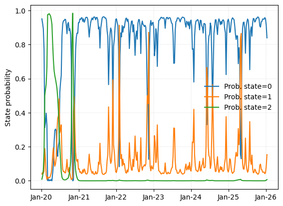

```python
def plot_timeseries(data, yaxis_label, xaxis_label=None):
    """
    This function makes a simple line plot for timeseries data.

    data: pandas DataFrame to be plotted. The index is a DateTimeIndex; index is formatted as 'mmm-yy'.
        Data to be plotted are along the columns.
    yaxis_label: str; the label to be used for the y-axis.
    yaxis_label: str; the label to be used for the y-axis; defaults to None.

    RETURN: The matplotlib.Figure and matplotlib.axes.Axes for the plot.
    """
    fig, ax = plt.subplots(nrows=1, ncols=1)
    ax.grid(visible=True, linestyle='dashed', lw=0.35, color='lightgray')
    sns.lineplot(data=data, dashes=False, ax=ax, lw=1.5)
    ax.xaxis.set_major_formatter(mdts.DateFormatter('%b-%y'))
    ax.set_xlabel(xlabel=xaxis_label)
    ax.set_ylabel(ylabel=yaxis_label)
    ax.legend(loc='best', framealpha=0, edgecolor=None)

    return fig, ax

fig, ax = plot_timeseries(data=onevar_n3_states.drop(labels='State', axis=1).loc[onevar_n3_states.index >= pd.to_datetime('2020-01-01')],
                          yaxis_label='State probability')
```

Fit the Hidden Markov Model for a number of states and see where the best fit is.

```python
possible_states = range(2, 9)

from sklearn.utils import check_random_state
random_state = check_random_state(42)

onevar_fitquality = pd.DataFrame(index=possible_states, columns=['Converged','AIC','BIC','Log likelihood'],dtype=object)

for ns in possible_states:
    print('Fitting for states = ' + str(ns))
    try:
        h = hmm.GaussianHMM(n_components=ns, covariance_type = 'full', n_iter=1000, tol=1e-04, random_state=random_state)
        h.fit(X=stock_df_w.values)
        onevar_fitquality.loc[ns, 'Converged'] = h.monitor_.converged
        onevar_fitquality.loc[ns, 'AIC'] = h.aic(X=stock_df_w.values)
        onevar_fitquality.loc[ns, 'BIC'] = h.bic(X=stock_df_w.values)
        onevar_fitquality.loc[ns, 'Log likelihood'] = h.score(X=stock_df_w.values)
    except Exception as e:
        print('Unable to fit for states = ' + str(ns))
        print(e)
onevar_fitquality[['AIC', 'BIC', 'Log likelihood']] = onevar_fitquality[['AIC', 'BIC', 'Log likelihood']].astype(np.float64)
```

```
Fitting for states = 2
Fitting for states = 3
```

```
Fitting for states = 4
```

[output not shown]

```
Fitting for states = 5
Fitting for states = 6
```

```
Fitting for states = 7
Fitting for states = 8
```

```python
onevar_fitquality
```

|  | Converged | AIC | BIC | Log likelihood |
| --- | --- | --- | --- | --- |
| 2 | True | -5109.136077 | -5072.471630 | 2561.568039 |
| 3 | True | -5117.631254 | -5044.302360 | 2572.815627 |
| 4 | True | -5105.485885 | -4985.016986 | 2575.742942 |
| 5 | True | -5117.882792 | -4939.798334 | 2592.941396 |
| 6 | True | -5104.459223 | -4858.283648 | 2599.229612 |
| 7 | True | -5073.772950 | -4749.030702 | 2598.886475 |
| 8 | True | -5052.609066 | -4638.824588 | 2605.304533 |

```python
COLOUR_PALETTE = 'colorblind'
def plot_lines_twoaxes(data, primary_columns, secondary_columns, primary_yaxis_label, secondary_yaxis_label,
                       xaxis_label= None):
    """
    This function makes a line plot with a primary and a secondary axis.

    data: pandas DataFrame to be plotted. The index is numeric; index is formatted as per the default for its data type.
        Data to be plotted are along the columns.
    primary_columns: List specifying column names to be plotted on the primary axis.
    secondary_columns: List specifying column names to be plotted on the secondary axis.
    primary_yaxis_label: str; the label to be used for the primary y-axis.
    secondary_yaxis_label: str; the label to be used for the secondary y-axis.
    xaxis_label: str; the label to be used for the x-axis; defaults to None.

    RETURN: The matplotlib.Figure and matplotlib.axes.Axes for the plot.
    """
    n_primary = len(primary_columns)
    n_secondary = len(secondary_columns)

    palette_primary = sns.color_palette(palette=COLOUR_PALETTE, n_colors=n_primary + n_secondary)[:n_primary]
    palette_secondary = sns.color_palette(palette=COLOUR_PALETTE, n_colors=n_primary + n_secondary)[n_primary:(n_primary + n_secondary)]

    fig, ax = plt.subplots(nrows=1, ncols=1)

    ax.grid(visible=True, linestyle='dashed', lw=0.35, color='lightgray')
    sns.lineplot(data=data[primary_columns], dashes=False, ax=ax, lw=1.5, palette=palette_primary)
    ax.set_ylabel(ylabel=primary_yaxis_label)
    ax.legend().set_visible(False)

    ax2 = ax.twinx()
    ax2.grid(visible=False)
    sns.lineplot(data=data[secondary_columns].rename(mapper={c: ' '.join([c, '(right)']) for c in secondary_columns}, axis=1),
                 ax=ax2, dashes=False, lw=1.5, palette=palette_secondary)
    ax2.set_ylabel(ylabel=secondary_yaxis_label)
    ax2.legend().set_visible(False)

    ax.legend(ax.get_legend_handles_labels()[0] + ax2.get_legend_handles_labels()[0],
              ax.get_legend_handles_labels()[1] + ax2.get_legend_handles_labels()[1],
              loc='best', framealpha=0, edgecolor=None)

    return fig, ax, ax2
```

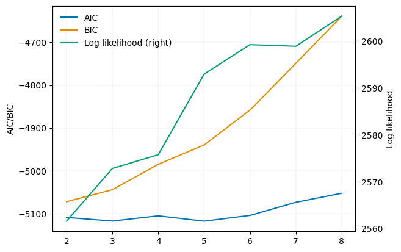

```python
fig, ax_primary, ax_secondary = plot_lines_twoaxes(data=onevar_fitquality, primary_columns=['AIC', 'BIC'],
                                                   secondary_columns=['Log likelihood'], primary_yaxis_label='AIC/BIC',
                                                   secondary_yaxis_label='Log likelihood')
```

### 3.3.2 Gaussian Mixture Models

```python
from sklearn.mixture import GaussianMixture
onevar_n3 = GaussianMixture(n_components=n_state, tol=1e-04,max_iter=1000,random_state=check_random_state(42)).fit(X=stock_df_w.values)

onevar_n3_fitquality = pd.Series(index=['AIC','BIC'],
                                 data=[onevar_n3.aic(stock_df_w.values),
                                       onevar_n3.bic(stock_df_w.values)])

onevar_n3_params = pd.DataFrame(index=[' '.join(['State',str(j)]) for j in range(n_state)],
                                columns=['Mean', 'Std.dev.', 'Weight'], dtype=np.float64)
onevar_n3_params['Mean'] = onevar_n3.means_.reshape(n_state)
onevar_n3_params['Std.dev.'] = np.sqrt(onevar_n3.covariances_.reshape(n_state))
onevar_n3_params['Weight'] = onevar_n3.weights_.reshape(n_state)

onevar_n3_states = pd.DataFrame(index=stock_df_w.index,
                                columns=['State'] + ['='.join(['Prob. state', str(j)]) for j in range(n_state)],
                                dtype=np.float64)
onevar_n3_states['State'] = onevar_n3.predict(X=stock_df_w.values)
onevar_n3_states['State'] = onevar_n3_states['State'].astype(np.int8)
onevar_n3_states[['='.join(['Prob. state', str(j)]) for j in range(n_state)]] = onevar_n3.predict_proba(X=stock_df_w.values)
```

```python
onevar_n3_fitquality
```

```
AIC   -4834.398100
BIC   -4792.495874
dtype: float64
```

```python
onevar_n3_params.map(lambda x: '{:.4f}'.format(x))
```

|  | Mean | Std.dev. | Weight |
| --- | --- | --- | --- |
| State 0 | 0.0032 | 0.0293 | 0.7883 |
| State 1 | 0.0070 | 0.0952 | 0.1481 |
| State 2 | -0.0153 | 0.0597 | 0.0636 |

```python
onevar_n3_states.loc[onevar_n3_states.index >= pd.to_datetime('2025-06-01')].style.format(
    {'='.join(['Prob. state', str(j)]): '{:.1%}' for j in range(n_state)})
```

| Date | State | Prob. state=0 | Prob. state=1 | Prob. state=2 |
| --- | --- | --- | --- | --- |
| 2025-06-01 00:00:00 | 0 | 90.3% | 6.2% | 3.6% |
| 2025-06-08 00:00:00 | 0 | 89.7% | 6.6% | 3.7% |
| 2025-06-15 00:00:00 | 0 | 49.0% | 31.0% | 20.0% |
| 2025-06-22 00:00:00 | 0 | 89.7% | 6.0% | 4.2% |
| 2025-06-29 00:00:00 | 0 | 89.1% | 7.1% | 3.8% |
| 2025-07-06 00:00:00 | 0 | 90.4% | 5.7% | 3.9% |
| 2025-07-13 00:00:00 | 0 | 91.1% | 5.5% | 3.4% |
| 2025-07-20 00:00:00 | 0 | 90.3% | 6.1% | 3.6% |
| 2025-07-27 00:00:00 | 1 | 35.8% | 39.8% | 24.5% |
| 2025-08-03 00:00:00 | 0 | 91.1% | 5.3% | 3.6% |
| 2025-08-10 00:00:00 | 0 | 90.0% | 6.3% | 3.6% |
| 2025-08-17 00:00:00 | 0 | 67.4% | 19.4% | 13.3% |
| 2025-08-24 00:00:00 | 0 | 88.8% | 6.5% | 4.6% |
| 2025-08-31 00:00:00 | 0 | 91.0% | 5.4% | 3.6% |
| 2025-09-07 00:00:00 | 0 | 89.6% | 6.1% | 4.3% |
| 2025-09-14 00:00:00 | 0 | 84.1% | 9.3% | 6.6% |
| 2025-09-21 00:00:00 | 0 | 88.5% | 7.6% | 4.0% |
| 2025-09-28 00:00:00 | 0 | 90.3% | 5.7% | 4.0% |
| 2025-10-05 00:00:00 | 0 | 90.0% | 6.3% | 3.6% |
| 2025-10-12 00:00:00 | 0 | 91.2% | 5.3% | 3.5% |
| 2025-10-19 00:00:00 | 0 | 91.2% | 5.3% | 3.5% |
| 2025-10-26 00:00:00 | 0 | 91.2% | 5.4% | 3.4% |
| 2025-11-02 00:00:00 | 0 | 80.7% | 11.3% | 8.0% |
| 2025-11-09 00:00:00 | 0 | 79.9% | 11.7% | 8.3% |
| 2025-11-16 00:00:00 | 0 | 88.2% | 6.9% | 4.9% |
| 2025-11-23 00:00:00 | 0 | 85.6% | 8.4% | 6.0% |
| 2025-11-30 00:00:00 | 0 | 90.7% | 5.9% | 3.5% |
| 2025-12-07 00:00:00 | 0 | 90.0% | 6.4% | 3.6% |
| 2025-12-14 00:00:00 | 0 | 87.4% | 7.3% | 5.2% |
| 2025-12-21 00:00:00 | 0 | 91.3% | 5.3% | 3.5% |
| 2025-12-28 00:00:00 | 0 | 90.9% | 5.4% | 3.7% |
| 2026-01-04 00:00:00 | 0 | 86.1% | 8.1% | 5.8% |
| 2026-01-11 00:00:00 | 0 | 78.0% | 15.6% | 6.4% |

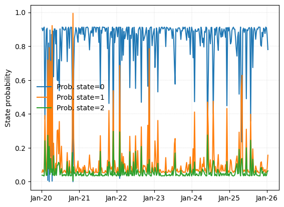

```python
fig, ax = plot_timeseries(data=onevar_n3_states.drop(labels='State', axis=1).loc[onevar_n3_states.index >= pd.to_datetime('2020-01-01')],
                          yaxis_label='State probability')
```

```python
possible_states = range(2, 9)

random_state = check_random_state(42)

onevar_fitquality = pd.DataFrame(index=possible_states, columns=['Converged', 'AIC', 'BIC', 'Log likelihood'],
                                 dtype=object)

for ns in possible_states:
    print('Fitting for states = ' + str(ns))
    try:
        g = GaussianMixture(n_components=ns, tol=1e-04, max_iter=1000,
                            random_state=check_random_state(42)).fit(X=stock_df_w.values)
        onevar_fitquality.loc[ns, 'Converged'] = g.converged_
        onevar_fitquality.loc[ns, 'AIC'] = g.aic(X=stock_df_w.values)
        onevar_fitquality.loc[ns, 'BIC'] = g.bic(X=stock_df_w.values)
        onevar_fitquality.loc[ns, 'Log likelihood'] = g.score(X=stock_df_w.values)
    except Exception as e:
        print('Unable to fit for states = ' + str(ns))
        print(e)
onevar_fitquality[['AIC', 'BIC', 'Log likelihood']] = onevar_fitquality[['AIC', 'BIC', 'Log likelihood']].astype(np.float64)
```

```
Fitting for states = 2
Fitting for states = 3
Fitting for states = 4
Fitting for states = 5
```

```
Fitting for states = 6
Fitting for states = 7
Fitting for states = 8
```

|  | Converged | AIC | BIC | Log likelihood |
| --- | --- | --- | --- | --- |
| 2 | True | -4835.137996 | -4808.949105 | 1.741602 |
| 3 | True | -4834.398100 | -4792.495874 | 1.743493 |
| 4 | True | -4833.651181 | -4776.035621 | 1.745381 |
| 5 | True | -4838.551382 | -4765.222487 | 1.749300 |
| 6 | True | -4831.108305 | -4742.066075 | 1.748781 |
| 7 | True | -4825.369277 | -4720.613713 | 1.748875 |
| 8 | True | -4833.960258 | -4713.491360 | 1.754119 |

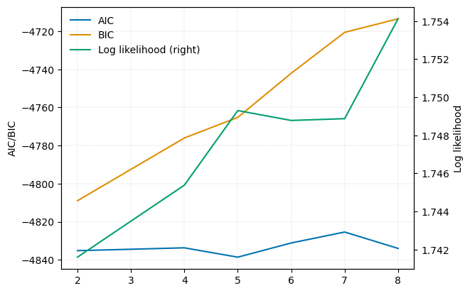

```python
fig, ax_primary, ax_secondary = plot_lines_twoaxes(data=onevar_fitquality, primary_columns=['AIC', 'BIC'],
                                                   secondary_columns=['Log likelihood'], primary_yaxis_label='AIC/BIC',
                                                   secondary_yaxis_label='Log likelihood')
onevar_fitquality
```

# 4. Style Analysis and Back Testing

I use Fama French data library industry returns to construct a few portfolios using different weighting schemes and back test these portfolios' performance.

```python
ind49_rets = get_fff_returns('49_Industry_Portfolios')
ind30_rets = get_fff_returns('30_Industry_Portfolios')
ind49_mcap = get_ind_market_caps('49_Industry_Portfolios', weights=True)
```

[output not shown]

[output cut: 72 more lines]

[output not shown]

## 4.1 Back Test Util Functions

```python
def weight_ew(r,cap_weights=None, max_cw_mult=None, microcap_threshold=None, **kwargs):
    """
    Returns the weights of the EW portfolio based on the asset returns "r" as a DataFrame
    """
    n = len(r.columns)
    ew = pd.Series(1/n, index=r.columns)
    if cap_weights is not None:
        cw = cap_weights.loc[r.index[0]] # starting cap weight
        ## exclude microcaps
        if microcap_threshold is not None and microcap_threshold > 0:
            microcap = cw < microcap_threshold
            ew[microcap] = 0
            ew = ew/ew.sum()
        #limit weight to a multiple of capweight
        if max_cw_mult is not None and max_cw_mult > 0:
            ew = np.minimum(ew, cw*max_cw_mult)
            ew = ew/ew.sum() #reweight
    return ew

def weight_cw(r, cap_weights, **kwargs):
    """
    Returns the weights of the CW portfolio based on the time series of capweights
    """
    w = cap_weights.loc[r.index[1]]
    return w/w.sum()

def backtest_ws(r, estimation_window=60, weighting=weight_ew, **kwargs):
    """
    Backtests a given weighting scheme, given some parameters:
    r : asset returns to use to build the portfolio
    estimation_window: the window to use to estimate parameters
    weighting: the weighting scheme to use, must be a function that takes "r", and a variable number of keyword-value arguments
    """
    n_periods = r.shape[0]
    # return windows
    windows = [(start, start+estimation_window) for start in range(n_periods-estimation_window+1)]
    weights = [weighting(r.iloc[win[0]:win[1]], **kwargs) for win in windows]
    # convert list of weights to DataFrame
    weights = pd.DataFrame(weights, index=r.iloc[estimation_window-1:].index, columns=r.columns)
    # return weights
    returns = (weights * r).sum(axis="columns",  min_count=1) #mincount is to generate NAs if all inputs are NAs
    return returns
```

```python
#import statsmodels.stats.moment_helpers as mh
def cc_cov(r, **kwargs):
    """
    Estimates a covariance matrix by using the Elton/Gruber Constant Correlation model
    """
    rhos = r.corr()
    n = rhos.shape[0]
    # this is a symmetric matrix with diagonals all 1 - so the mean correlation is ...
    rho_bar = (rhos.values.sum()-n)/(n*(n-1))
    ccor = np.full_like(rhos, rho_bar)
    np.fill_diagonal(ccor, 1.)
    sd = r.std()
    ccov = ccor * np.outer(sd, sd)
#     mh.corr2cov(ccor, sd)
    return pd.DataFrame(ccov, index=r.columns, columns=r.columns)

def portfolio_return(weights, returns):
    """
    Computes the return on a portfolio from constituent returns and weights
    weights are a numpy array or Nx1 matrix and returns are a numpy array or Nx1 matrix
    """
    return weights.T @ returns

def portfolio_vol(weights, covmat):
    """
    Computes the vol of a portfolio from a covariance matrix and constituent weights
    weights are a numpy array or N x 1 maxtrix and covmat is an N x N matrix
    """
    vol = (weights.T @ covmat @ weights)**0.5
    return vol

def msr(riskfree_rate, er, cov):
    """
    Returns the weights of the portfolio that gives you the maximum sharpe ratio
    given the riskfree rate and expected returns and a covariance matrix
    """
    n = er.shape[0]
    init_guess = np.repeat(1/n, n)
    bounds = ((0.0, 1.0),) * n # an N-tuple of 2-tuples!
    # construct the constraints
    weights_sum_to_1 = {'type': 'eq',
                        'fun': lambda weights: np.sum(weights) - 1
    }
    def neg_sharpe(weights, riskfree_rate, er, cov):
        """
        Returns the negative of the sharpe ratio
        of the given portfolio
        """
        r = portfolio_return(weights, er)
        vol = portfolio_vol(weights, cov)
        return -(r - riskfree_rate)/vol

    weights = minimize(neg_sharpe, init_guess,
                       args=(riskfree_rate, er, cov), method='SLSQP',
                       options={'disp': False},
                       constraints=(weights_sum_to_1,),
                       bounds=bounds)
    return weights.x

def gmv(cov):
    """
    Returns the weights of the Global Minimum Volatility portfolio
    given a covariance matrix
    """
    n = cov.shape[0]
    return msr(0, np.repeat(1, n), cov)

def sample_cov(r, **kwargs):
    """
    Returns the sample covariance of the supplied returns
    """
    return r.cov()

def weight_gmv(r, cov_estimator=sample_cov, **kwargs):
    """
    Produces the weights of the GMV portfolio given a covariance matrix of the returns
    """
    est_cov = cov_estimator(r, **kwargs)
    return gmv(est_cov)

def shrinkage_cov(r, delta=0.5, **kwargs):
    """
    Covariance estimator that shrinks between the Sample Covariance and the Constant Correlation Estimators
    """
    prior = cc_cov(r, **kwargs)
    sample = sample_cov(r, **kwargs)
    return delta*prior + (1-delta)*sample
```

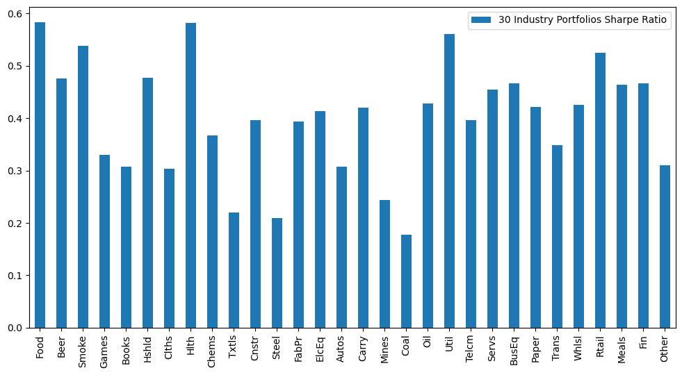

```python
sr = pd.DataFrame({"30 Industry Portfolios Sharpe Ratio":sharpe_ratio(ind30_rets["1945":],0.03,12)})
sr.plot.bar(figsize=(12,6));
```

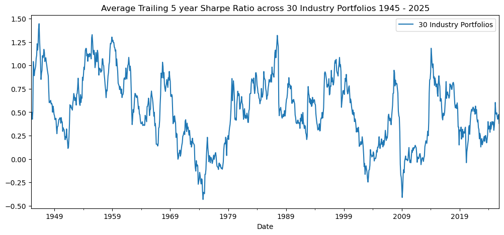

```python
ax = ind30_rets.rolling(60).apply(sharpe_ratio, raw=True, kwargs={"riskfree_rate":0.03, "periods_per_year":12}).mean(axis=1)["1945":].plot(figsize=(12,5),label="30 Industry Portfolios",legend=True)
ax.set_title("Average Trailing 5 year Sharpe Ratio across 30 Industry Portfolios 1945 - 2025");
```